# Introduction to Inferential Statistics

Author

Yi Lu

Published

November 11, 2026

## Example 1: NJ happiness

Suppose you conduct a survey of adults in New Jersey and ask each respondent to rate their happiness on a scale from 0 to 100. The following map shows the average happiness score for each county. What conclusions can you draw?

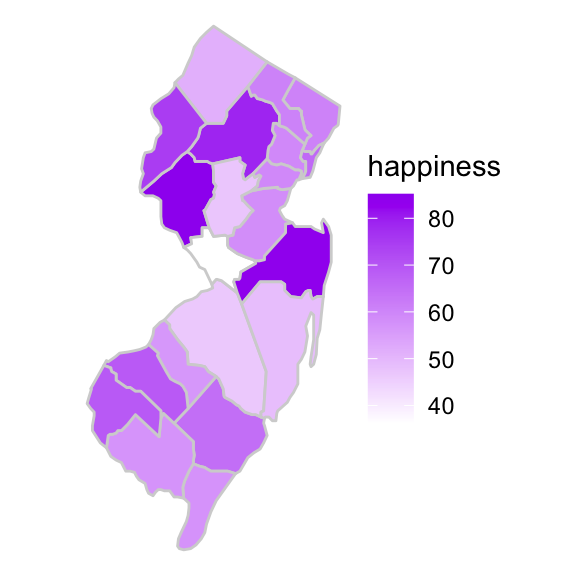

**What’s the truth**

Any pattern you see is actually **due to random chance**. The happiness score is randomly generated for each of the 21 counties using the *same* underlying distribution (**rnorm(21,mean=60,sd=15)**).

## Example 2: US crime rates

This map is based on the USArrests dataset. What conclusions can you draw?

```
           Murder Assault UrbanPop Rape
Alabama      13.2     236       58 21.2
Alaska       10.0     263       48 44.5
Arizona       8.1     294       80 31.0
Arkansas      8.8     190       50 19.5
California    9.0     276       91 40.6
Colorado      7.9     204       78 38.7
```

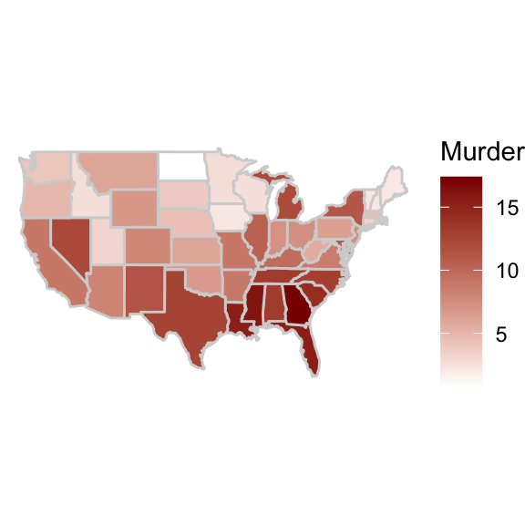

**What’s the truth**

Unknown. Any pattern you see can be due to random chance, or can be statistically significant.

## Pattern you see in the data can be due to random chance!

```r
sample(c('Success','Fail'),size=50,replace=T)
```

```
 [1] "Fail"    "Fail"    "Fail"    "Fail"    "Success" "Success" "Fail"
 [8] "Fail"    "Fail"    "Success" "Fail"    "Fail"    "Success" "Fail"
[15] "Fail"    "Fail"    "Success" "Success" "Fail"    "Success" "Success"
[22] "Success" "Fail"    "Fail"    "Success" "Success" "Fail"    "Success"
[29] "Success" "Success" "Fail"    "Success" "Success" "Fail"    "Fail"
[36] "Fail"    "Success" "Fail"    "Success" "Fail"    "Success" "Fail"
[43] "Success" "Fail"    "Fail"    "Success" "Fail"    "Success" "Fail"
[50] "Fail"
```

We see streaks of Fails and Successes, but these are all due to random chance!

## Inferential statistics

We have been working with many different data and can describe the data in many ways (summary statistics, visualizations, correlations, etc.). However, **data does NOT equal to the truth!**

- In any survey data: respondents are only a random sample of the population. If we see that, for instance, 23% of **respondents** in the `child.care` dataset used childcare, it does not mean that exactly 23% of the entire U.S. population used childcare.
- In an NBA example: a player’s *true* ability (of shooting field goals, for instance) is a **latent variable** that cannot be directly measured. For instance, in the 2024 NBA season, Mikal Bridges has a higher field goal percentage than Jalen Green, but it doesn’t necessarily mean that Mikal Bridges is better than Jalen Green; maybe he is just lucky (i.e., his success is “due to random chance”).

```r
library(Lock5Data)
NBAPlayers2024 %>%
  filter(Starts > 80, MinPerGame > 30 ) %>%
  select(Player, Pos, Team, Games, FGAttempt, FGMade, FGPct) %>%
  arrange(desc(Team))
```

```
              Player Pos Team Games FGAttempt FGMade FGPct
1   Domantas Sabonis   C  SAC    82      1068    634 0.594
2        Jalen Green  SG  HOU    82      1332    563 0.423
3 Michael Porter Jr.  SF  DEN    81      1079    522 0.484
4      Mikal Bridges  SF  BRK    82      1294    564 0.436
```

- Another way to think about this: most of the time, *data is not reproducible*: if I conduct the same survey again with different respondents, I will get a different percentage of respondents using childcare; Mikal Bridges is better than Jalen Green in 2024, but it is not a guarantee that he will also be better in 2025.

## p-value and statistical significance

- **Descriptive statistics**, also referred to as Exploratory Data Analysis (EDA), is about describing the *data*
- **Inferential statistics** is about generalizing the conclusion to the *entire population* and/or the *truth*
- Typically, a “hypothesis test” is conducted and a **p-value** is obtained
  - If p-value is large (>0.05): the conclusion is *not* significant and due to random chance
  - If p-value is small (<0.05): the conclusion is statistically significant
- Definition of p-value: the probability of observing the data (i.e., test statistic) as extreme, or more extreme, than the one obtained, assuming the null hypothesis is true.

## Example 3: drug effect on tumor size

Suppose a new drug is developed to treat a certain type of cancer and has been tested on 20 patients. Is the drug effective?

```
    tumsize1  tumsize2    patient
1  15.454042  6.926204  patient 1
2   7.286632 14.213477  patient 2
3  11.628681 11.079898  patient 3
4  14.428575 10.482909  patient 4
5   9.524580  9.125362  patient 5
6  11.471811  9.149994  patient 6
7   9.493480  9.774322  patient 7
8   5.206460 10.899869  patient 8
9  10.554134 10.676206  patient 9
10 16.671018  9.649528 patient 10
11 15.437937  8.548358 patient 11
12 10.478542 10.441172 patient 12
13 14.385787 10.130264 patient 13
14 10.809951  9.408377 patient 14
15  7.876401 12.626095 patient 15
16 12.141398  8.267080 patient 16
17 11.616720  6.881314 patient 17
18  9.512484  8.905779 patient 18
19 11.369541 14.949419 patient 19
20 12.846685  9.973217 patient 20
```

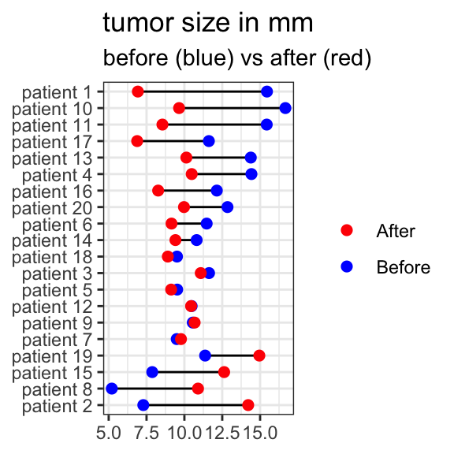

Remember, the data alone does not tell us whether the drug is effective; we need to evaluate the statistical significance. We decide to conduct a **paired samples t-test**. What is the conclusion here?

```r
t.test(df.drug$tumsize1, df.drug$tumsize2, paired = TRUE)
```

```
    Paired t-test

data:  df.drug$tumsize1 and df.drug$tumsize2
t = 1.3812, df = 19, p-value = 0.1833
alternative hypothesis: true mean difference is not equal to 0
95 percent confidence interval:
 -0.6722583  3.2808597
sample estimates:
mean difference
       1.304301
```

**Solution**

The p-value is large (0.1833 > 0.05), so we conclude that the drug is not statistically significant in reducing tumor size.

**What’s the truth**

Any pattern you see is indeed due to random chance. The tumor sizes before and after taking the drug are both randomly, and independently generated for each patient using the *same* underlying distribution (**rgamma(20,shape=20,rate=2)**).

## Intuition behind p-value: a thought experiment

Suppose your data looks like this: Matt, he is wearing a blue t-shirt, a pair of jeans, some sneakers, sunglasses, and a baseball cap. He is holding his phone and listening to music on his headphones.

Question: which scenario is more likely?

- A: Matt is about to run a race.
- B: Matt is not about to run a race.

**Key idea**

IF Matt is about to run a race, what **should** he look like? In other words, IF scenario A is true, what **should** your data look like? This is called a **reference distribution**.

**Reference distribution**

[figure not shown]

Runners at the [2026 NYC marathon](https://en.wikipedia.org/wiki/2026_New_York_City_Marathon)

If your data is very “unusual” or “extreme” compared to the reference distribution, you would **reject** scenario A on the basis of your data.

If not, i.e., your data looks pretty “likely” under the reference distribution, you would **fail to reject** scenario A.

How likely is your data under the reference distribution? This is essentially what the **p-value** measures! Hence: **small** p-value -> **unlikely** data -> reject the null hypothesis (scenario A).

Question: if you decide scenario B is more likely, did you **prove** with certainty that Matt is not about to run a race?

**Key idea**

No, you cannot **prove** that Matt is not about to run a race. You are just saying that the evidence is very strong against scenario A, meaning that your data is very unlikely under scenario A (i.e., it’s unlikely that Matt would wear jeans to a race).

## Example 1: NJ happiness revisited

Consider two scenarios:

- A: every county in NJ is equally happy, on average.
- B: Morris county is more happy than all of the other counties.

You conduct your survey and look at your data (e.g., generate a map that looks like example 1), but how do you decide between scenario A and B?

Key idea: if **scenario A** is true, what **should** your data look like?

**Reference distribution under scenario A**

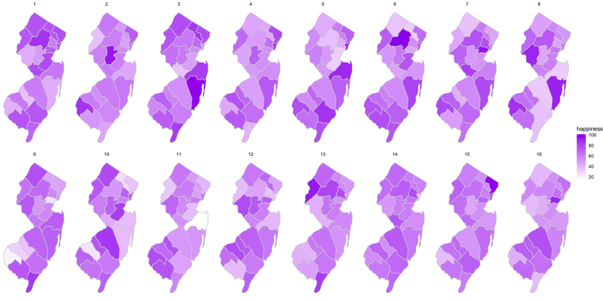

Now, if your data looks like this, would you **reject** scenario A?

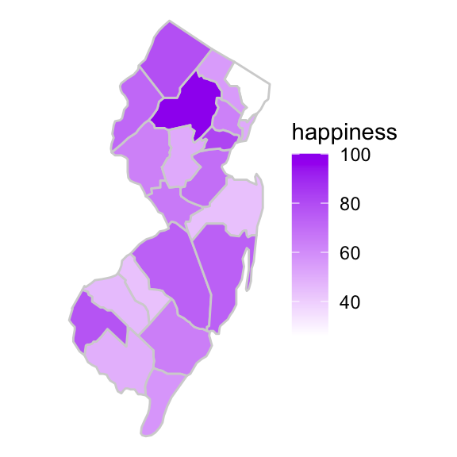

What if your data looks like this?

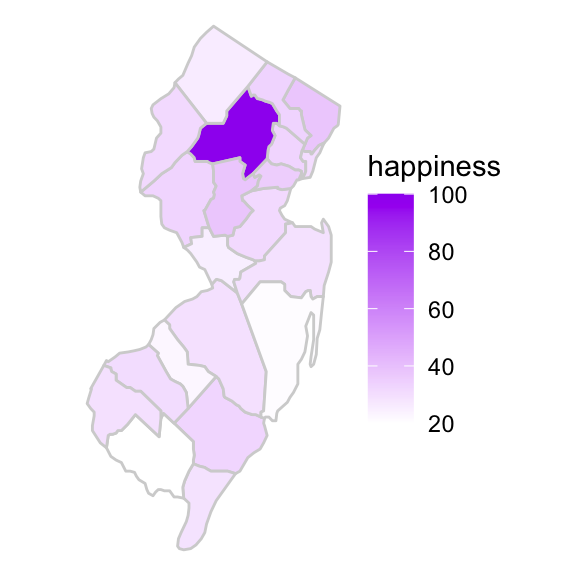

## Example 3: drug effect revisited

In the drug effect example, we can summarize the data by calculating the **mean difference** between the tumor sizes before and after treatment.

```r
df.drug$tumsize1 - df.drug$tumsize2
```

[output not shown]

```r
mean(df.drug$tumsize1 - df.drug$tumsize2)
```

```
[1] 1.304301
```

We need to decide between:

- Scenario A: The drug has no effect (the null hypothesis)
- Scenario B: The drug has an effect (the alternative hypothesis)

Reference distribution: what **should** the mean difference look like **if the drug has no effect**?

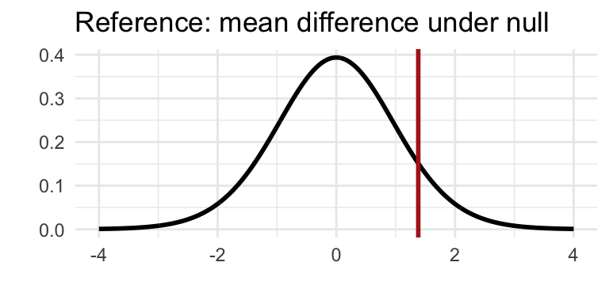

(This reference distribution is a t-distribution, that’s why it’s called a paired samples **t-test**. The derivation is based on the Central Limit Theorem.)

Is our observed value (1.3) very extreme? What would you conclude?

**Show solution**

No, visually a value of 1.3 (red vertical line) is not very extreme. Intuitively, the observed data is “pretty possible” under the no-effect reference distribution, so we do not have strong evidence to reject the no-effect null hypothesis. In fact, recall that the p-value is 0.1833, which is greater than 0.05, so we conclude that the drug is not statistically significant in reducing tumor size. (The two-sided p-value of 0.1833 means that the area to the right of 1.3 is 0.09165, and the area to the left of -1.3 is also 0.09165, so the total area in the two tails is 0.1833.)